# Project 7: Difference-in-Differences and Synthetic Control

## Discussion Questions

- Card/Krueger’s original piece utilized the fact that towns on either side of the Delaware river are likely to be quite similar to one another in terms of demographics, economics, etc. Why is that intuition harder to replicate with this data?
- **Well, besides pre-2014 uninsurance rates and populations, the characteristics of California and Florida couldn’t be further apart. There are just vast differences between states, even those that are adjacent. Not only in terms of demographics and economics, but also a myriad of confounding variables related to healthcare and health insurance. These data are only at the state level, which makes this apples-to-apples comparison very difficult.**:
- What are the strengths and weaknesses of using the parallel trends assumption in difference-in-differences estimates?
- **A strength of the approach is that when you can justify that you’ve met all the assumptions, it’s an extremely strong research design for isolating a causal effect. However, in practice, those assumptions (like the parallel trends assumption) are extremeley difficult to meet, which is a major limitation.**:

# Synthetic Control

Estimate Synthetic Control

Although several states did not expand Medicaid on January 1, 2014, many did later on. In some cases, a Democratic governor was elected and pushed for a state budget that included the Medicaid expansion, whereas in others voters approved expansion via a ballot initiative. The 2018 election was a watershed moment where several Republican-leaning states elected Democratic governors and approved Medicaid expansion. In cases with a ballot initiative, the state legislature and governor still must implement the results via legislation. For instance, Idaho voters approved a Medicaid expansion in the 2018 election, but it was not implemented in the state budget until late 2019, with enrollment beginning in 2020.

Do the following:

- Choose a state that adopted the Medicaid expansion after January 1, 2014. Construct a non-augmented synthetic control and plot the results (both pre-treatment fit and post-treatment differences). Also report the average ATT and L2 imbalance.

```r
# non-augmented synthetic control

# create a treatment indicator
# ----------
penn <- medicaid_expansion %>%
  mutate(treatment = case_when(State == "Pennsylvania" & year >= 2015 ~ 1,
                               TRUE ~ 0))

# synthetic control
# ---------
syn <-
  augsynth(uninsured_rate ~ treatment,
           State,
           year,
           penn,
           progfunc = "None",
           scm = T)
```

```
## One outcome and one treatment time found. Running single_augsynth.
```

```r
# summary
summary(syn)
```

```
##
## Call:
## single_augsynth(form = form, unit = !!enquo(unit), time = !!enquo(time),
##     t_int = t_int, data = data, progfunc = "None", scm = ..2)
##
## Average ATT Estimate (p Value for Joint Null):  -0.0109   ( 0.61 )
## L2 Imbalance: 0.001
## Percent improvement from uniform weights: 99.5%
##
## Avg Estimated Bias: NA
##
## Inference type: Conformal inference
##
##  Time Estimate 95% CI Lower Bound 95% CI Upper Bound p Value
##  2015   -0.010             -0.032              0.013   0.228
##  2016   -0.008             -0.030              0.014   0.258
##  2017   -0.013             -0.035              0.009   0.255
##  2018   -0.013             -0.035              0.009   0.365
##  2019   -0.011             -0.033              0.011   0.256
##  2020   -0.011             -0.033              0.011   0.237
```

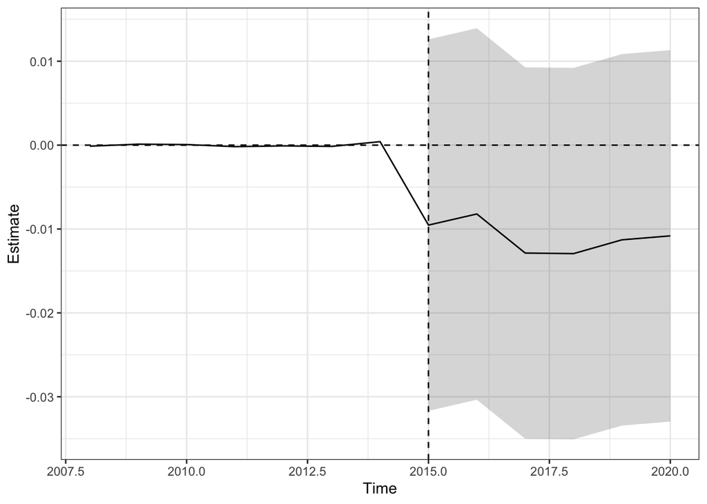

```r
## ATT = -0.0109
## L2 Imbalance = .001

# plot
plot(syn)
```

- Re-run the same analysis but this time use an augmentation (default choices are Ridge, Matrix Completion, and GSynth). Create the same plot and report the average ATT and L2 imbalance.

```r
# augmented synthetic control
synRidge <-
  augsynth(uninsured_rate ~ treatment,
           State,
           year,
           penn,
           progfunc = "ridge",
           scm = T)
```

```
## One outcome and one treatment time found. Running single_augsynth.
```

```r
# summary
summary(synRidge)
```

```
##
## Call:
## single_augsynth(form = form, unit = !!enquo(unit), time = !!enquo(time),
##     t_int = t_int, data = data, progfunc = "ridge", scm = ..2)
##
## Average ATT Estimate (p Value for Joint Null):  -0.0109   ( 0.61 )
## L2 Imbalance: 0.001
## Percent improvement from uniform weights: 99.5%
##
## Avg Estimated Bias: 0.000
##
## Inference type: Conformal inference
##
##  Time Estimate 95% CI Lower Bound 95% CI Upper Bound p Value
##  2015   -0.010             -0.032              0.013   0.257
##  2016   -0.008             -0.030              0.014   0.253
##  2017   -0.013             -0.035              0.009   0.253
##  2018   -0.013             -0.035              0.009   0.370
##  2019   -0.011             -0.033              0.011   0.252
##  2020   -0.011             -0.033              0.011   0.245
```

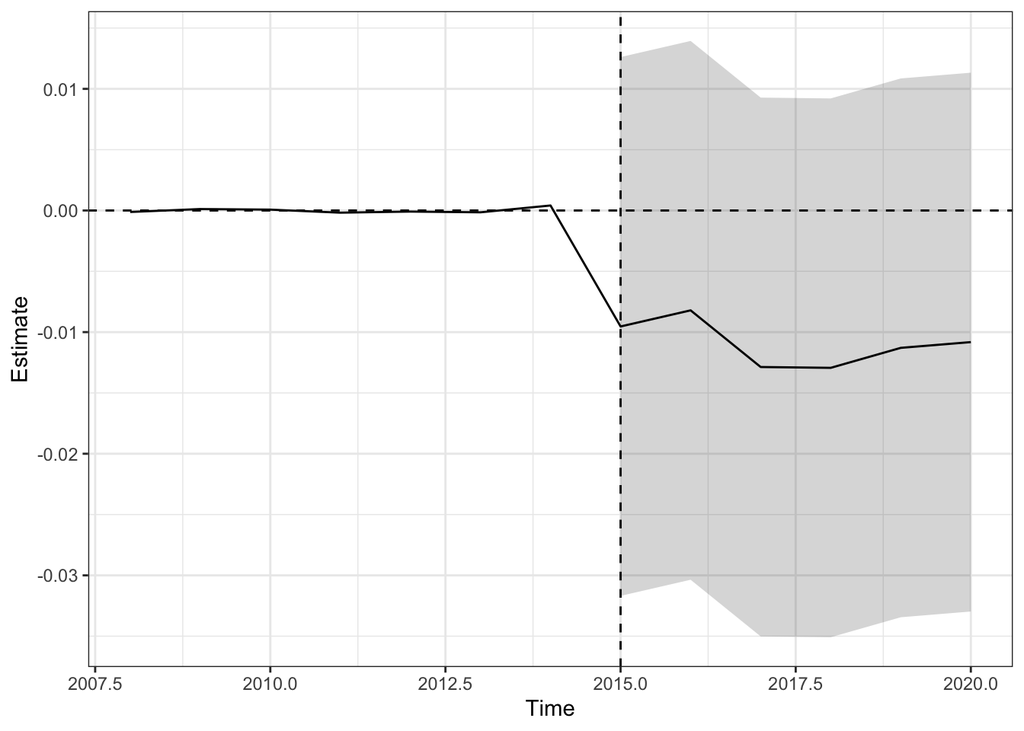

```r
## ATT = -0.0109
## L2 Imbalance = .001

# plot
plot(synRidge)
```

- Plot barplots to visualize the weights of the donors.

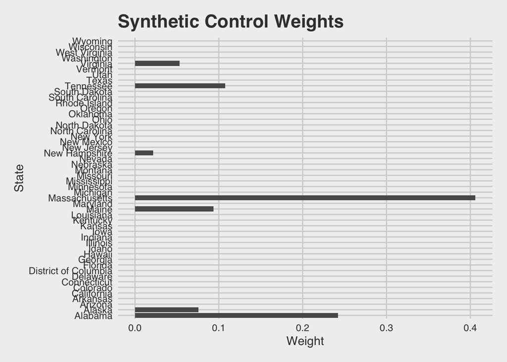

```r
# barplots of weights

# For synthetic
data.frame(syn$weights) %>%
  tibble::rownames_to_column('State') %>%
  ggplot() +
  geom_bar(aes(x = State,
               y = syn.weights),
           stat = 'identity') +
  coord_flip() +
  theme_fivethirtyeight() +
  theme(axis.title = element_text()) +
  ggtitle('Synthetic Control Weights') +
  xlab('State') +
  ylab('Weight')
```

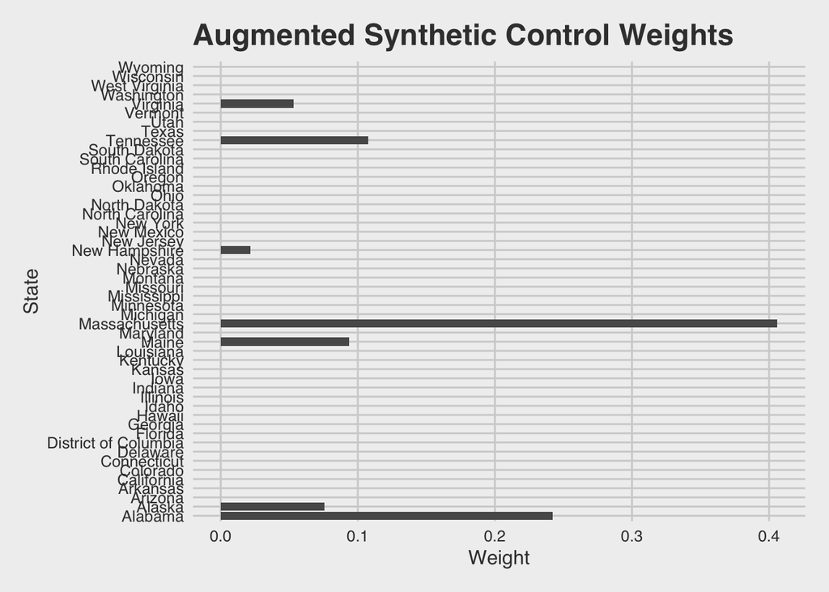

```r
# For augmented synthetic
data.frame(synRidge$weights) %>%
  tibble::rownames_to_column('State') %>%
  ggplot() +
  geom_bar(aes(x = State, y = synRidge.weights),
           stat = 'identity') +
  coord_flip() +
  theme_fivethirtyeight() +
  theme(axis.title = element_text()) +
  ggtitle('Augmented Synthetic Control Weights') +
  xlab('State') +
  ylab('Weight')
```

**HINT**: Is there any preprocessing you need to do before you allow the program to automatically find weights for donor states?